# Module 9: Solutions to Recommended Exercises

TMA4268 Statistical Learning V2023

Kenneth Aase, Emma Skarstein, Daesoo Lee, Stefanie Muff

Department of Mathematical Sciences, NTNU

March 16, 2023

## Problem 2

### a)

The curve is a circle with center $(-1,2)$ and radius $2$. You can sketch the curve by hand. If you want to do it in R, you can use the function `symbols()` (this is a bit advanced, though):

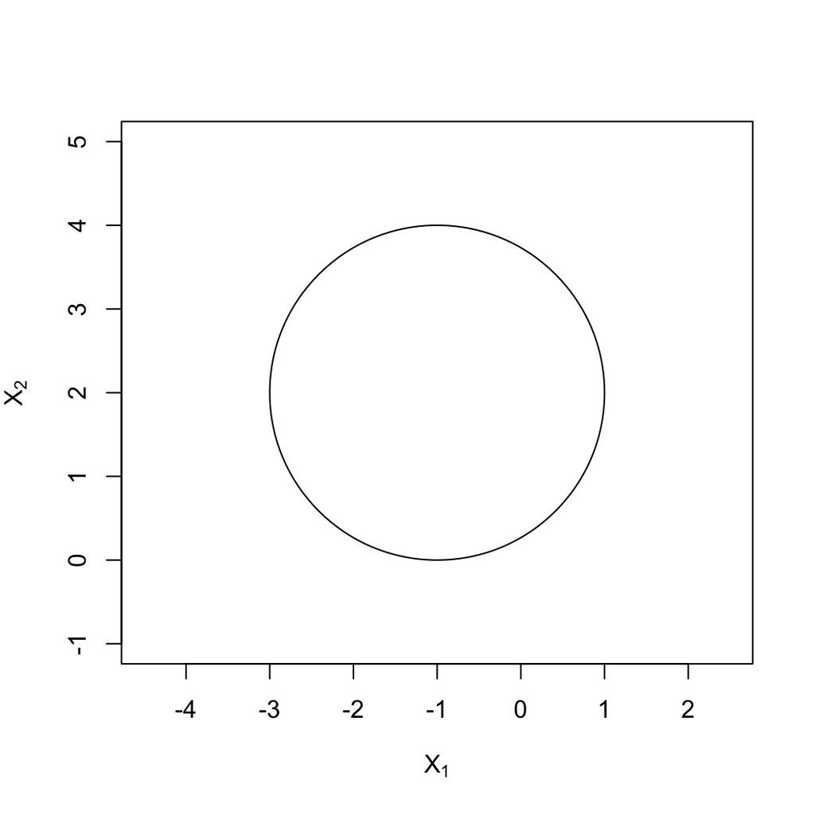

```r
# initialize a plot
plot(NA,
     NA,
     type = "n", # does not produce any points or lines
     xlim = c(-4, 2),
     ylim = c(-1, 5),
     xlab = expression(X[1]),
     ylab = expression(X[2]),
     asp = 1)
symbols(c(-1), c(2), circles = c(2), add = TRUE, inches = FALSE)
```

### b)

Again, feel free to do this by hand. A simple R solution could look like this:

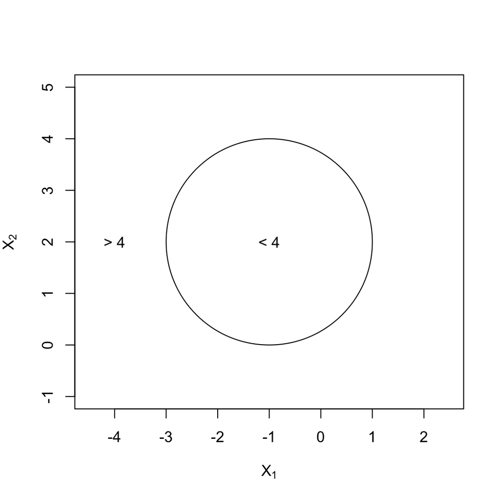

```r
# initialize a plot
plot(NA,
     NA,
     type = "n", # does not produce any points or lines
     xlim = c(-4, 2),
     ylim = c(-1, 5),
     xlab = expression(X[1]),
     ylab = expression(X[2]),
     asp = 1)
symbols(c(-1), c(2), circles = c(2), add = TRUE, inches = FALSE)
text(c(-1), c(2), "< 4")
text(c(-4), c(2), "> 4")
```

### c)

You can do this by hand. Here we again use R and color the points according to the class they belong to:

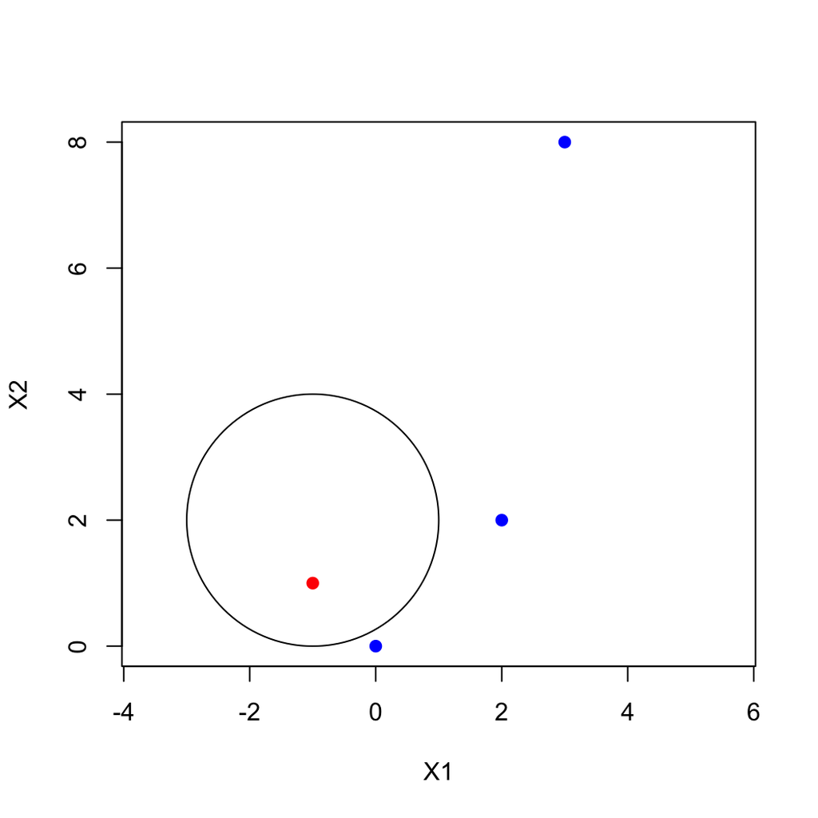

```r
plot(c(0, -1, 2, 3),
     c(0, 1, 2, 8),
     col = c("blue", "red", "blue", "blue"),
     type = "p",
     pch = 19,
     asp = 1,
     xlab = "X1",
     ylab = "X2")
symbols(c(-1), c(2), circles = c(2), add = TRUE, inches = FALSE)
```

### d)

Since equation
$$(1 + X_1)^2 + (2 - X_2)^2
= 4.$$
or

$$X_1^2 + X_2^2 + 2X_1 - 4X_2 +1 =
0$$
includes quadratic terms, the decision boundary is not linear, though it’s linear in terms of $X_1^2,$ $X_2^2,$ $X_1,$ and $X_2.$

## Problem 3

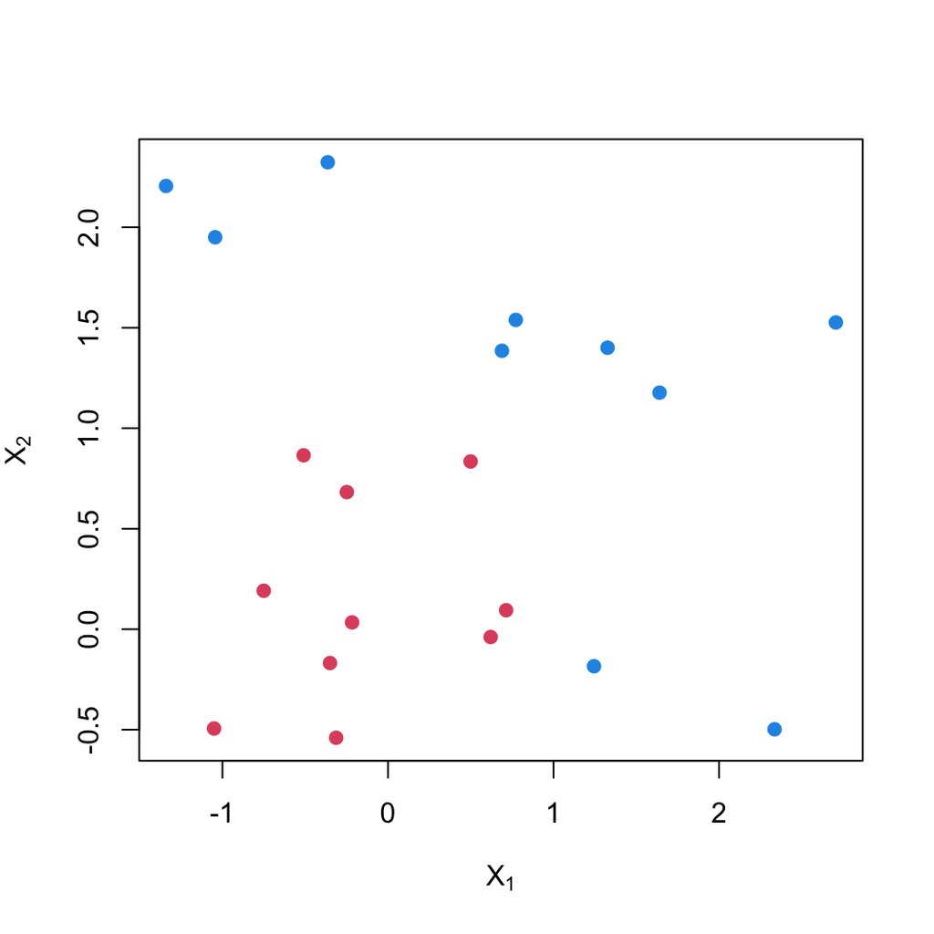

```r
# code taken from video by Trevor Hastie
set.seed(10111)
x <- matrix(rnorm(40), 20, 2)
y <- rep(c(-1, 1), c(10, 10))
x[y == 1, ] <- x[y == 1, ] + 1
plot(x, col = y + 3, pch = 19, xlab = expression(X[1]), ylab = expression(X[2]))
```

```r
dat <- data.frame(x, y = as.factor(y))
```

### a)

```r
library(e1071)
svmfit <- svm(y ~ ., data = dat, kernel = "linear", cost = 10, scale = FALSE)

# grid for plotting
make.grid <- function(x, n = 75) {
  # takes as input the data matrix x
  # and number of grid points n in each direction
  # the default value will generate a 75x75 grid

  grange <- apply(x, 2, range) # range for x1 and x2
  # Sequence from the lowest to the upper value of x1
  x1 <- seq(from = grange[1, 1], to = grange[2, 1], length.out = n)
  # Sequence from the lowest to the upper value of x2
  x2 <- seq(from = grange[1, 2], to = grange[2, 2], length.out = n)
  # Create a uniform grid according to x1 and x2 values
  expand.grid(X1 = x1, X2 = x2)
}
```

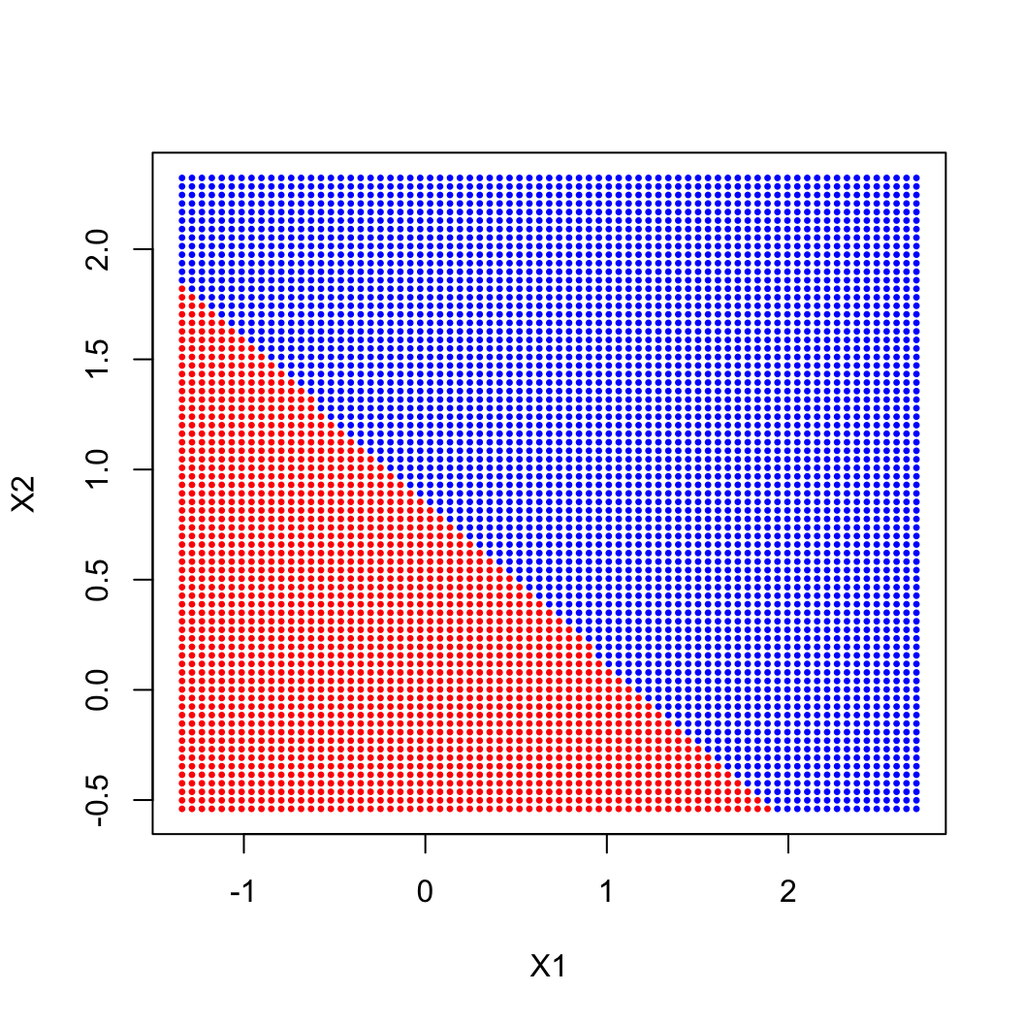

```r
x <- as.matrix(dat[, c("X1", "X2")])
xgrid <- make.grid(x)
ygrid <- predict(svmfit, xgrid)
plot(xgrid, col = c("red", "blue")[as.numeric(ygrid)], pch = 20, cex = 0.5)
```

### b)

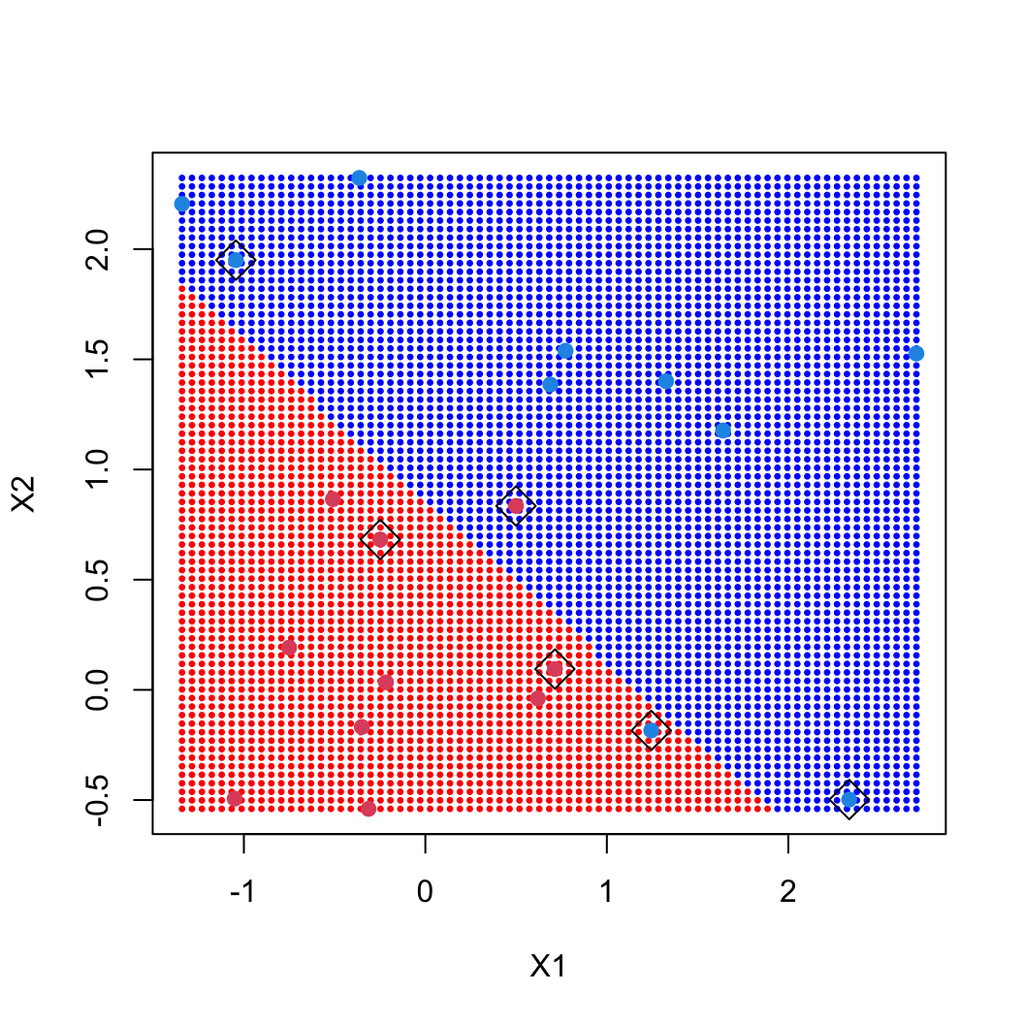

```r
plot(xgrid, col = c("red", "blue")[as.numeric(ygrid)], pch = 20, cex = 0.5)
points(x, col = y + 3, pch = 19)
points(x[svmfit$index, ], pch = 5, cex = 2)
```

### c)

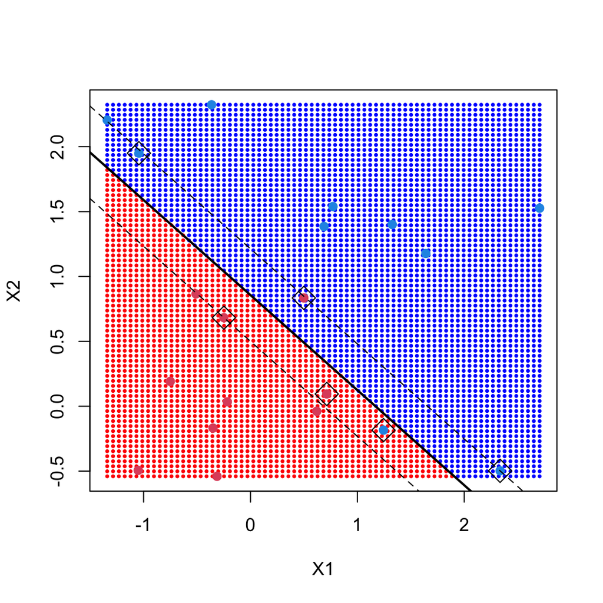

```r
beta <- drop(t(svmfit$coefs) %*% x[svmfit$index, ])
beta0 <- svmfit$rho
plot(xgrid, col = c("red", "blue")[as.numeric(ygrid)], pch = 20, cex = 0.5)
points(x, col = y + 3, pch = 19)
points(x[svmfit$index, ], pch = 5, cex = 2)
abline(beta0 / beta[2], -beta[1] / beta[2], lwd = 2) # Class boundary
abline((beta0 - 1) / beta[2], -beta[1] / beta[2], lty = 2) # Class boundary-margin
abline((beta0 + 1) / beta[2], -beta[1] / beta[2], lty = 2) # Class boundary+margin
```

## Problem 4

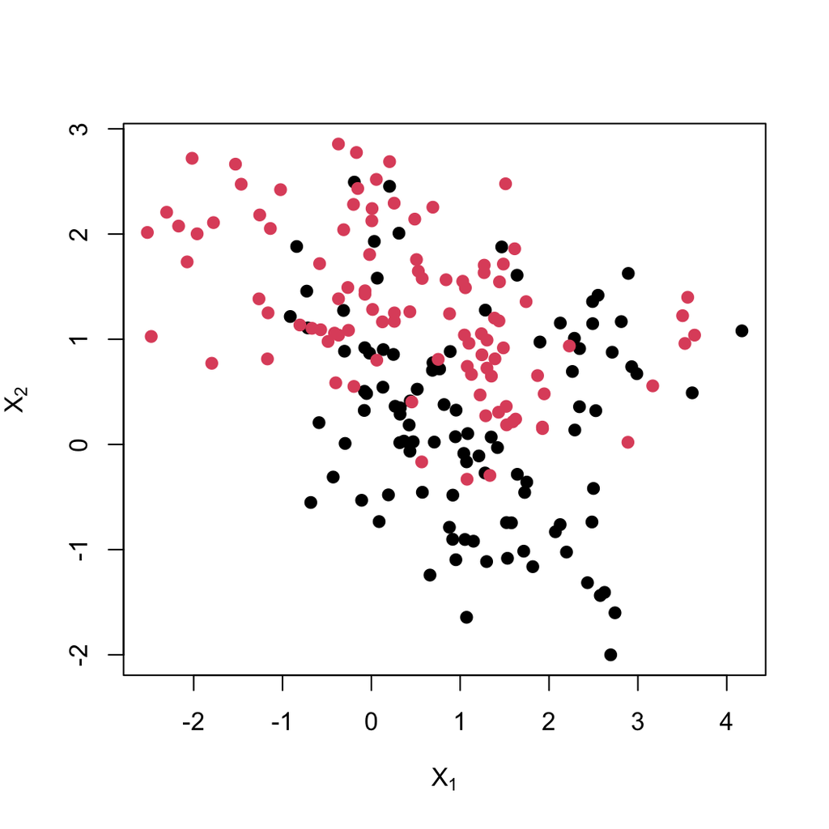

```r
load(url("https://web.stanford.edu/~hastie/ElemStatLearn/datasets/ESL.mixture.rda"))
#names(ESL.mixture)
rm(x, y)
attach(ESL.mixture)
plot(x, col = y + 1, pch = 19, xlab = expression(X[1]), ylab = expression(X[2]))
```

```r
dat <- data.frame(y = factor(y), x)
```

```r
r.cv <- tune(svm,
             factor(y) ~ .,
             data = dat,
             kernel = "radial",
             ranges = list(cost = c(0.01, 0.1, 1, 5, 10, 100, 1000),
                           gamma = c(0.01, 0.1, 1, 10, 100)))
summary(r.cv)
```

```
##
## Parameter tuning of 'svm':
##
## - sampling method: 10-fold cross validation
##
## - best parameters:
##  cost gamma
##     1    10
##
## - best performance: 0.165
##
## - Detailed performance results:
##     cost gamma error dispersion
## 1  1e-02 1e-02 0.525 0.14191155
## 2  1e-01 1e-02 0.525 0.14191155
```

[output cut: 33 more lines]

```r
fit <- r.cv$best.model
```

Now we plot the non-linear decision boundary, and add the training points.

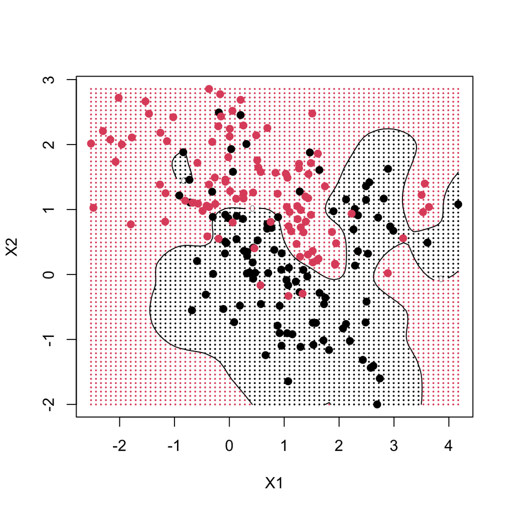

```r
xgrid <- make.grid(x)
ygrid <- predict(fit, xgrid)
plot(xgrid, col = as.numeric(ygrid), pch = 20, cex = 0.2)
points(x, col = y + 1, pch = 19)

# decision boundary
func <- predict(fit, xgrid, decision.values = TRUE)
func <- attributes(func)$decision
contour(unique(xgrid[, 1]),
        unique(xgrid[, 2]),
        matrix(func, 75, 75),
        level = 0,
        add = TRUE) #svm boundary
```

## Problem 5

### a)

```r
library(ISLR)
data(OJ)
#head(OJ)
n <- nrow(OJ)
set.seed(4268)
train <- sample(1:n, 800)
OJ.train <- OJ[train, ]
OJ.test <- OJ[-train, ]
```

### b)

```r
library(e1071)
linear <- svm(Purchase ~ .,
              data = OJ,
              subset = train,
              kernel = "linear",
              cost = 0.01)
summary(linear)
```

```
##
## Call:
## svm(formula = Purchase ~ ., data = OJ, kernel = "linear", cost = 0.01,
##     subset = train)
##
##
## Parameters:
##    SVM-Type:  C-classification
##  SVM-Kernel:  linear
##        cost:  0.01
##
## Number of Support Vectors:  431
##
##  ( 217 214 )
##
##
## Number of Classes:  2
##
## Levels:
##  CH MM
```

We have $431$ Support vectors, where $217$ belong to the class CH (Citrus Hill) and $214$ belong to the class MM (Minute Maid Orange Juice).

### c)

```r
pred.train <- predict(linear, OJ.train)
(ta <- table(OJ.train$Purchase, pred.train))
```

```
##     pred.train
##       CH  MM
##   CH 431  56
##   MM  78 235
```

```r
msrate <- 1 - sum(diag(ta)) / sum(ta)
msrate
```

```
## [1] 0.1675
```

```r
pred.test <- predict(linear, OJ.test)
(ta <- table(OJ.test$Purchase,  pred.test))
```

```
##     pred.test
##       CH  MM
##   CH 143  23
##   MM  25  79
```

```r
msrate <- 1 - sum(diag(ta)) / sum(ta)
msrate
```

```
## [1] 0.1777778
```

### d)

```r
set.seed(4268)
cost.val <- 10^seq(-2, 1, by = 0.25)
tune.cost <- tune(svm,
                  Purchase ~ .,
                  data = OJ.train,
                  kernel = "linear",
                  ranges = list(cost = cost.val))
#summary(tune.cost)
```

### e)

```r
svm.linear <- svm(Purchase ~ .,
                  kernel = "linear",
                  data = OJ.train,
                  cost = tune.cost$best.parameter$cost)
train.pred <- predict(svm.linear, OJ.train)
```

```r
(ta <- table(OJ.train$Purchase, train.pred))
```

```
##     train.pred
##       CH  MM
##   CH 434  53
##   MM  73 240
```

```r
msrate.train.linear <- 1 - sum(diag(ta)) / sum(ta)
msrate.train.linear
```

```
## [1] 0.1575
```

```r
test.pred <- predict(svm.linear, OJ.test)
(ta <- table(OJ.test$Purchase, test.pred))
```

```
##     test.pred
##       CH  MM
##   CH 143  23
##   MM  23  81
```

```r
msrate.test.linear <- 1 - sum(diag(ta)) / sum(ta)
msrate.test.linear
```

```
## [1] 0.1703704
```

### f)

Radial Kernel Model

```r
svm.radial <- svm(Purchase ~ ., kernel = "radial", data = OJ.train)
#summary(svm.radial)
```

Train and test error rate

```r
pred.train <- predict(svm.radial, OJ.train)
(ta <- table(OJ.train$Purchase, pred.train))
```

```
##     pred.train
##       CH  MM
##   CH 446  41
##   MM  72 241
```

```r
msrate.train.radial <- 1 - sum(diag(ta)) / sum(ta)
msrate.train.radial
```

```
## [1] 0.14125
```

```r
pred.test <- predict(svm.radial, OJ.test)
(ta <- table(OJ.test$Purchase,  pred.test))
```

```
##     pred.test
##       CH  MM
##   CH 145  21
##   MM  25  79
```

```r
msrate.test.radial <- 1 - sum(diag(ta)) / sum(ta)
msrate.test.radial
```

```
## [1] 0.1703704
```

Optimal cost

```r
set.seed(4268)
cost.val <- 10^seq(-2, 1, by = 0.25)
tune.cost <- tune(svm,
                  Purchase ~ .,
                  data = OJ.train,
                  kernel = "radial",
                  ranges = list(cost = cost.val))
#summary(tune.cost)
```

```r
svm.radial <- svm(Purchase ~ .,
                  kernel = "radial",
                  data = OJ.train,
                  cost = tune.cost$best.parameter$cost)
train.pred <- predict(svm.radial, OJ.train)
```

Train and test error for optimal cost

```r
(ta <- table(OJ.train$Purchase,  train.pred))
```

```
##     train.pred
##       CH  MM
##   CH 450  37
##   MM  73 240
```

```r
msrate.train.linear <- 1 - sum(diag(ta)) / sum(ta)
msrate.train.linear
```

```
## [1] 0.1375
```

```r
test.pred <- predict(svm.radial, OJ.test)
(ta <- table(OJ.test$Purchase, test.pred))
```

```
##     test.pred
##       CH  MM
##   CH 146  20
##   MM  28  76
```

```r
msrate.test.linear <- 1 - sum(diag(ta)) / sum(ta)
msrate.test.linear
```

```
## [1] 0.1777778
```

### g)

Polynomial Kernel Model of degree 2

```r
svm.poly <- svm(Purchase ~ .,
                kernel = "polynomial",
                degree = 2,
                data = OJ.train)
#summary(svm.poly)
```

Train and test error rate

```r
pred.train <- predict(svm.poly, OJ.train)
(ta <- table(OJ.train$Purchase, pred.train))
```

```
##     pred.train
##       CH  MM
##   CH 453  34
##   MM 109 204
```

```r
msrate.train.poly <- 1 - sum(diag(ta)) / sum(ta)
msrate.train.poly
```

```
## [1] 0.17875
```

```r
pred.test <- predict(svm.poly, OJ.test)
(ta <- table(OJ.test$Purchase, pred.test))
```

```
##     pred.test
##       CH  MM
##   CH 152  14
##   MM  33  71
```

```r
msrate.test.poly <- 1 - sum(diag(ta)) / sum(ta)
msrate.test.poly
```

```
## [1] 0.1740741
```

Optimal cost

```r
set.seed(4268)
cost.val <- 10^seq(-2, 1, by = 0.25)
tune.cost <- tune(svm,
                  Purchase ~ .,
                  data = OJ.train,
                  kernel = "poly",
                  degree = 2,
                  ranges = list(cost = cost.val))
#summary(tune.cost)
```

```r
svm.poly <- svm(Purchase ~ .,
                kernel = "poly",
                degree = 2,
                data = OJ.train,
                cost = tune.cost$best.parameter$cost)
train.pred <- predict(svm.poly, OJ.train)
```

Train and test error for optimal cost

```r
(ta <- table(OJ.train$Purchase, train.pred))
```

```
##     train.pred
##       CH  MM
##   CH 452  35
##   MM  84 229
```

```r
msrate.train.poly <- 1 - sum(diag(ta)) / sum(ta)
msrate.train.poly
```

```
## [1] 0.14875
```

```r
test.pred <- predict(svm.poly, OJ.test)
(ta <- table(OJ.test$Purchase, test.pred))
```

```
##     test.pred
##       CH  MM
##   CH 148  18
##   MM  27  77
```

```r
msrate.test.poly <- 1 - sum(diag(ta)) / sum(ta)
msrate.test.poly
```

```
## [1] 0.1666667
```

### h)

For the three choices of kernels and for the optimal cost we have

```r
msrate <- cbind(c(msrate.train.linear, msrate.train.radial, msrate.train.poly),
                c(msrate.test.linear, msrate.test.radial, msrate.test.poly))
rownames(msrate) <- c("linear", "radial", "polynomial")
colnames(msrate) <- c("msrate.train", "msrate.test")
msrate
```

```
##            msrate.train msrate.test
## linear          0.13750   0.1777778
## radial          0.14125   0.1703704
## polynomial      0.14875   0.1666667
```